# FinalMAT360

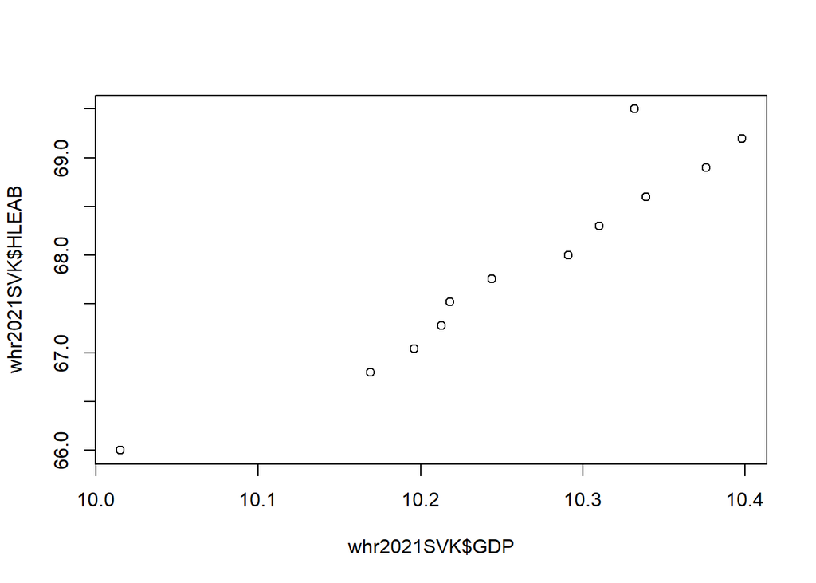

```r
#residuals vs fitted values seem doesnt show a non-linear relationship

#partial plots
plot(whr2021SVK$GDP,whr2021SVK$HLEAB) #linear
```

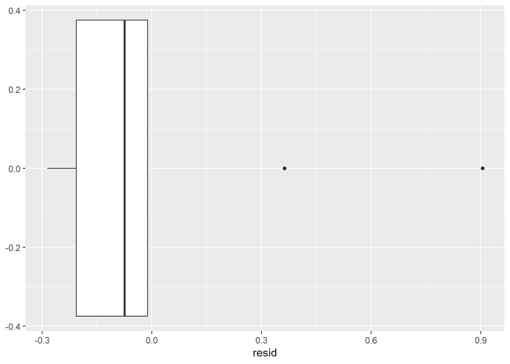

```r
#check boxplot for outliers
whr2021SVK$resid = linMod$residuals
whr2021SVK$pred = linMod$fitted.values
ggplot(data=whr2021SVK, aes(x=resid))+
  geom_boxplot()
```

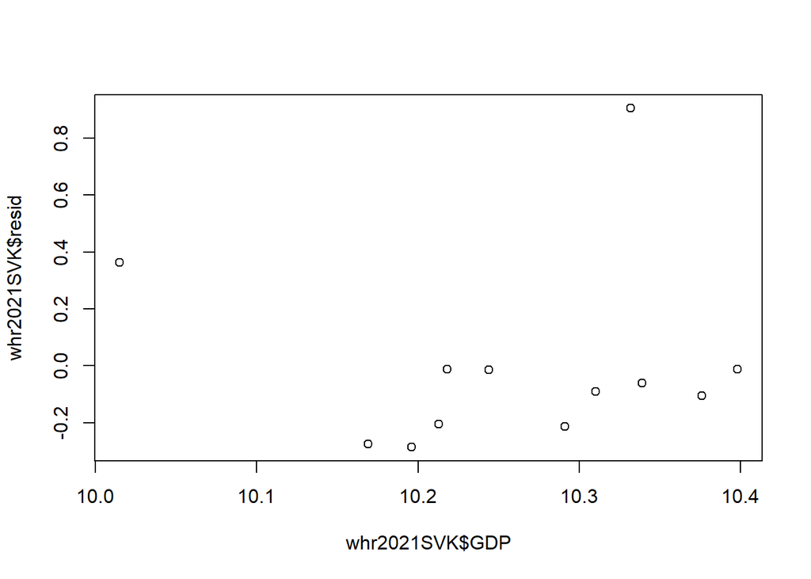

```r
#2 outliers, cant find a reason to remove them > Iam keeping them in


#4. Homoskedasticity of residuals
plot(whr2021SVK$GDP, whr2021SVK$resid)
```

```r
#its fire linear
```

Next, I checked the assumptions. The small sample size brought up challenges in the consideration of linearity, but ultimately I could make decisions with high precision. The plot of residuals vs fitted values seem doesn’t show a non-linear relationship. The partial plot of the independent and dependent variable was considered linear. The boxplot showed 2 outliers, but since there was no reason to believe they should be removed. I left them in. The plot for checking the homoskedasticity of residuals showed linearity.

The linear regression equation is: healthy life expectancy at birth = -27.83 +9.33*log GDP per capita

Creating knowledge about happiness would start with gathering data, many times through surveys, experiments, and then sharing it publicly for everyone This data is carefully analyzed and put together into a report that goes through peer review before it’s published in a scholarly journal. This diffiicult process gives credibility but reaches mainly experts and academics at first. Over time, as the findings of the study are shared better, they can influence not just further research, but also real-world policy and public opinion. This can have a significant impact despite the specialized start.